# Worksheet 1

### Exercise 1: Classification and Pruning

This problem involves the OJ data set which is part of the `ISLP` package.

(a) Create a training set containing a random sample of 800 observations, and a test set containing the remaining observations.

## [Worksheet 1: Decision Trees

#### Student Name: Jeevitha Bandi

```python
import pandas as pd
from ISLP import load_data
from sklearn.model_selection import train_test_split

# Load the OJ dataset
data = load_data('OJ')

# Creating a training (800 obs) and test set (remaining) with fixed random seed
train_set, test_set = train_test_split(data, train_size=800, random_state=1)
print(f"Training set size: {len(train_set)}")
print(f"Test set size: {len(test_set)}")
```

```
Training set size: 800
Test set size: 270
```

(b) Fit a tree to the training data, with Purchase as the response and the other variables as predictors. Produce summary statistics about the tree, and describe the results obtained. What is the training error rate? How many terminal nodes does the tree have?

```python
from sklearn.tree import DecisionTreeClassifier
from sklearn.metrics import accuracy_score

#features and target
X_train_raw = train_set.drop(columns='Purchase')
y_train = train_set['Purchase']

X_train = pd.get_dummies(X_train_raw)#Converting categorical variables to dummy variables since {ValueError: could not convert string to float: 'No'}

# Fitting a classification tree
tree_model = DecisionTreeClassifier(random_state=1)
tree_model.fit(X_train, y_train)

# Predicting on training data
train_preds = tree_model.predict(X_train)

# training error rate
train_accuracy = accuracy_score(y_train, train_preds)
train_error_rate = 1 - train_accuracy

# Number of terminal nodes (leaf nodes)
terminal_nodes = tree_model.get_n_leaves()

# Depth of the tree
tree_depth = tree_model.get_depth()

# Summary statistics
print(f"Training error rate: {train_error_rate:.4f}")
print(f"Number of terminal nodes (leaves): {terminal_nodes}")
print(f"Depth of the tree: {tree_depth}")
```

```
Training error rate: 0.0100
Number of terminal nodes (leaves): 164
Depth of the tree: 16
```

(c) Type in the name of the tree object in order to get a detailed text output. Pick one of the terminal nodes, and interpret the information displayed.

```python
from sklearn.tree import export_text

# Printing a textual summary of the decision tree
tree_rules = export_text(tree_model, feature_names=list(X_train.columns), max_depth=3)
print(tree_rules)
```

```
|--- LoyalCH <= 0.45
|   |--- LoyalCH <= 0.28
|   |   |--- LoyalCH <= 0.05
|   |   |   |--- StoreID <= 2.50
|   |   |   |   |--- truncated branch of depth 3
|   |   |   |--- StoreID >  2.50
|   |   |   |   |--- class: MM
|   |   |--- LoyalCH >  0.05
|   |   |   |--- WeekofPurchase <= 249.50
|   |   |   |   |--- truncated branch of depth 6
|   |   |   |--- WeekofPurchase >  249.50
|   |   |   |   |--- truncated branch of depth 7
|   |--- LoyalCH >  0.28
|   |   |--- SpecialCH <= 0.50
|   |   |   |--- SalePriceMM <= 2.04
|   |   |   |   |--- truncated branch of depth 10
|   |   |   |--- SalePriceMM >  2.04
|   |   |   |   |--- truncated branch of depth 13
|   |   |--- SpecialCH >  0.50
|   |   |   |--- LoyalCH <= 0.41
|   |   |   |   |--- truncated branch of depth 5
|   |   |   |--- LoyalCH >  0.41
|   |   |   |   |--- truncated branch of depth 2
|--- LoyalCH >  0.45
|   |--- LoyalCH <= 0.75
|   |   |--- PriceDiff <= -0.16
|   |   |   |--- STORE <= 2.50
|   |   |   |   |--- truncated branch of depth 7
|   |   |   |--- STORE >  2.50
|   |   |   |   |--- truncated branch of depth 7
|   |   |--- PriceDiff >  -0.16
|   |   |   |--- SalePriceMM <= 2.12
|   |   |   |   |--- truncated branch of depth 12
|   |   |   |--- SalePriceMM >  2.12
|   |   |   |   |--- truncated branch of depth 10
|   |--- LoyalCH >  0.75
|   |   |--- PriceDiff <= -0.39
|   |   |   |--- LoyalCH <= 0.98
|   |   |   |   |--- truncated branch of depth 2
|   |   |   |--- LoyalCH >  0.98
|   |   |   |   |--- truncated branch of depth 3
|   |   |--- PriceDiff >  -0.39
|   |   |   |--- WeekofPurchase <= 241.50
|   |   |   |   |--- truncated branch of depth 5
|   |   |   |--- WeekofPurchase >  241.50
|   |   |   |   |--- truncated branch of depth 7
```

In this analysis, the factors influencing a customer's choice of orange juice brand, specifically predicting a preference for Minute Maid (MM).

Key conditions for this prediction are as follows:

1. **Loyalty to Citrus Hill (LoyalCH)**:
   - **LoyalCH <= 0.45**: Indicates a low level of loyalty to Citrus Hill.
   - **LoyalCH <= 0.28**: Suggests an even lower level of loyalty.
   - **LoyalCH <= 0.05**: Points to minimal loyalty to Citrus Hill, potentially indicating that the customer is either new or has recently switched brands.
2. **Store Identification**:
   - **StoreID > 2.50**: The customer is shopping at a store with an ID greater than 2.5, which may indicate a different store chain or geographical region.

### Conclusion:

Based on these observations, customers who exhibit minimal loyalty to Citrus Hill and are shopping at various store chains (StoreID > 2.5) are predicted to opt for Minute Maid (MM). This prediction aligns with the understanding that customers who do not demonstrate brand loyalty, especially in specific shopping environments, are more inclined to choose MM as their orange juice brand.

(d) Create a plot of the tree, and interpret the results.

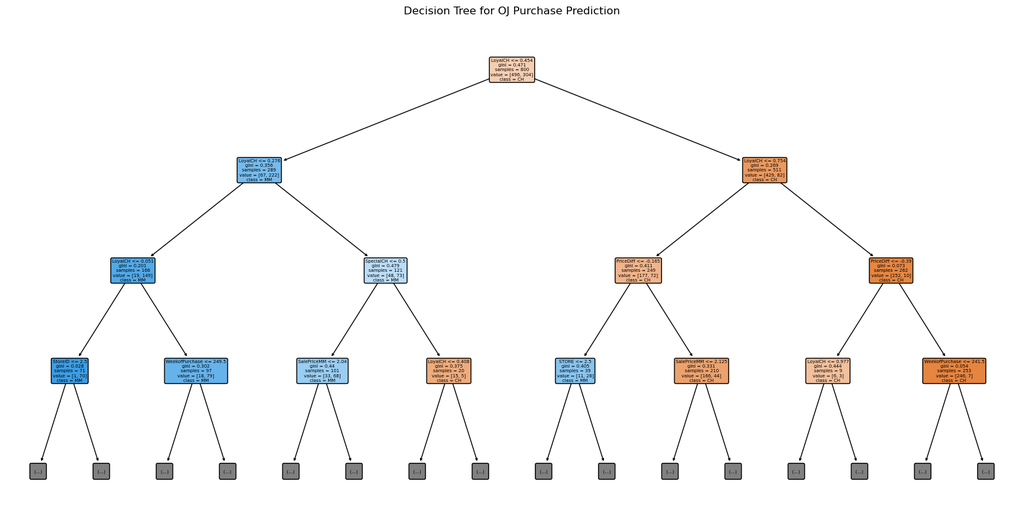

```python
import matplotlib.pyplot as plt
from sklearn.tree import plot_tree

plt.figure(figsize=(20, 10))
plot_tree(tree_model, feature_names=X_train.columns, class_names=tree_model.classes_, filled=True, max_depth=3, rounded=True)

plt.title("Decision Tree for OJ Purchase Prediction")
plt.show()
```

(e) Predict the response on the test data, and produce a confusion matrix comparing the test labels to the predicted test labels. What is the test error rate?

```
Test error rate: 0.2481
```

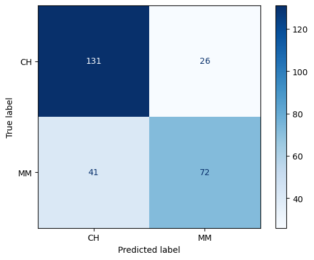

```python
from sklearn.metrics import confusion_matrix, ConfusionMatrixDisplay

X_test_raw = test_set.drop(columns='Purchase') # Preparing the test set (same encoding as training)
y_test = test_set['Purchase']

# Applying one-hot encoding to test set since model was trained on a one-hot encoding version of data
X_test = pd.get_dummies(X_test_raw) # this make sure the test set is encoded in the same way

# Aligning test columns with train columns (fill missing ones with 0)
X_test = X_test.reindex(columns=X_train.columns, fill_value=0)

test_preds = tree_model.predict(X_test)

# Confusion matrix
conf_matrix = confusion_matrix(y_test, test_preds, labels=tree_model.classes_)
disp = ConfusionMatrixDisplay(confusion_matrix=conf_matrix, display_labels=tree_model.classes_)
disp.plot(cmap='Blues')

# Test error rate
test_accuracy = accuracy_score(y_test, test_preds)
test_error_rate = 1 - test_accuracy

print(f"Test error rate: {test_error_rate:.4f}")
```

(f) Apply cross-validation to the training set in order to determine the optimal tree size.

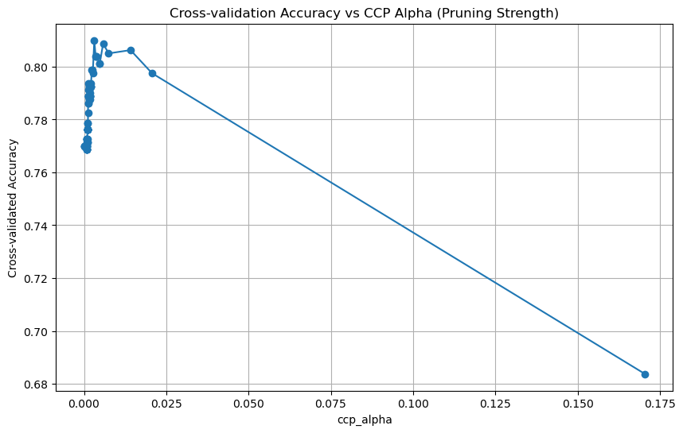

```
Optimal ccp_alpha: 0.00313
```

```python
# In decision tree, especially unpruned ones, the model can grow very deep and create many splits to fit the training data perfectly.
# this will lead to overfitting, to avoid, we use cost complexity pruning parameter, where it minimizes loss function

import numpy as np
import matplotlib.pyplot as plt
from sklearn.model_selection import cross_val_score

# Getting effective alphas and corresponding tree impurities
path = tree_model.cost_complexity_pruning_path(X_train, y_train)#applying cost-complexity pruning to determine the optimal tree size
#ccp_alphas Controls how much penalty given to tree complexity
ccp_alphas = path.ccp_alphas #tree would prune a split

trees = []
#looping over, for each one creating new decision tree that uses pruning strength and trains the tree
for alpha in ccp_alphas:
    clf = DecisionTreeClassifier(random_state=1, ccp_alpha=alpha)
    clf.fit(X_train, y_train)
    trees.append(clf)

# using 5 fold Cross-validation for each tree, trains on 4 tests on 1 and rotates
cv_scores = [np.mean(cross_val_score(tree, X_train, y_train, cv=5)) for tree in trees]

# CV accuracy vs alpha
plt.figure(figsize=(10, 6))
plt.plot(ccp_alphas, cv_scores, marker='o')
plt.xlabel("ccp_alpha")
plt.ylabel("Cross-validated Accuracy")
plt.title("Cross-validation Accuracy vs CCP Alpha (Pruning Strength)")
plt.grid(True)
plt.show()

# Get the best alpha (with highest mean CV score)
optimal_alpha = ccp_alphas[np.argmax(cv_scores)]
print(f"Optimal ccp_alpha: {optimal_alpha:.5f}")
```

(g) Produce a plot with tree size on the x-axis and cross-validated classification error rate on the y-axis.

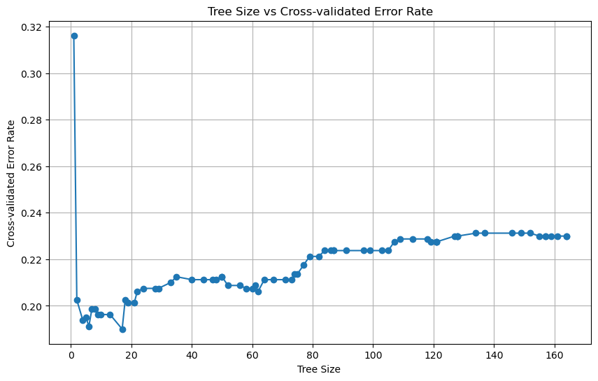

```python
tree_sizes = [tree.get_n_leaves() for tree in trees]
cv_error_rates = [1 - score for score in cv_scores]

import matplotlib.pyplot as plt

plt.figure(figsize=(10, 6))
plt.plot(tree_sizes, cv_error_rates, marker='o')
plt.xlabel("Tree Size ")
plt.ylabel("Cross-validated Error Rate")
plt.title("Tree Size vs Cross-validated Error Rate")
plt.grid(True)
plt.show()
```

(h) Which tree size corresponds to the lowest cross-validated classification error rate?

(i) Produce a pruned tree corresponding to the optimal tree size obtained using cross-validation. If cross-validation does not lead to selection of a pruned tree, then create a pruned tree with five terminal nodes.

```python
from sklearn.tree import plot_tree
import matplotlib.pyplot as plt

# Retrain tree with optimal ccp_alpha
pruned = DecisionTreeClassifier(random_state=1, ccp_alpha=0.00313)
pruned.fit(X_train, y_train)

print(f"Terminal nodes: {pruned.get_n_leaves()}")
print(f"Depth of the tree: {pruned.get_depth()}")
```

```
Terminal nodes: 18
Depth of the tree: 8
```

(j) Compare the training error rates between the pruned and unpruned trees. Which is higher?

```python
from sklearn.metrics import accuracy_score

pruned_preds = pruned.predict(X_train)

# Accuracy and error rate
pruned_accuracy = accuracy_score(y_train, pruned_preds)
pruned_error = 1 - pruned_accuracy

print(f"Pruned tree training error: {pruned_error:.4f}")
```

```
Pruned tree training error: 0.1312
```

An unpruned decision tree fits the training data very well, often leading to overfitting by memorizing noise along with relevant patterns. In contrast, a pruned tree has a higher training error since it is simpler, but this simplification improves its generalization ability and reduces overfitting risk. Consequently, while the pruned tree may perform worse on training data, it can achieve better or comparable results on test data, which is what truly matters.

(k) Compare the test error rates between the pruned and unpruned trees. Which is higher?

```python
test_preds = pruned.predict(X_test)

from sklearn.metrics import accuracy_score

# Accuracy and error for pruned tree
test_accuracy = accuracy_score(y_test, test_preds)
test_error = 1 - test_accuracy

print(f"Pruned tree test error: {test_error:.4f}")
```

```
Pruned tree test error: 0.2000
```

The unpruned tree shows a higher test error rate of 0.2481 compared to the pruned tree, which has a test error rate of 0.2000.

As a result, the pruned tree demonstrates superior performance on unseen data, making it the preferred model in this scenario. Although the pruned tree shows reduced accuracy on the training set, it benefits from better generalization by effectively avoiding overfitting.

### Exercise 2: Decision Trees for Regression

In the lab, a classification tree was applied to the Carseats data set after converting Sales into a qualitative response variable. Now we will seek to predict Sales using regression trees and related approaches, treating the response as a quantitative variable.

(a) Split the data set into a training set and a test set.

```python
data1 = load_data('Carseats')

train_set, test_set = train_test_split(data1, train_size=0.7, random_state=42)
#Spliting a training set with 70% of the observation and the rest test set with 30% and reproducibility

print(f"Training set size: {len(train_set)}")
print(f"Test set size: {len(test_set)}")
```

```
Training set size: 280
Test set size: 120
```

(b) Fit a regression tree to the training set. Plot the tree, and interpret the results. What test MSE do you obtain?

```python
from sklearn.tree import DecisionTreeRegressor
from sklearn.metrics import mean_squared_error

# Separate predictors and response
X_train = train_set.drop(columns='Sales')
y_train = train_set['Sales']

X_test = test_set.drop(columns='Sales')
y_test = test_set['Sales']

X_train = pd.get_dummies(X_train)
X_test = pd.get_dummies(X_test)

# Align columns
X_test = X_test.reindex(columns=X_train.columns, fill_value=0)

reg = DecisionTreeRegressor(random_state=1)
reg.fit(X_train, y_train)
```

```
DecisionTreeRegressor(random_state=1)
```